# Project 2 - Maryland Expenditures 2010 (3 of 3)

Jai Jeffryes

10/4/2019

```r
knitr::opts_chunk$set(echo = TRUE)
library(knitr)
library(openxlsx)
library(tidyr)
library(dplyr)
library(stringr)
library(ggplot2)
```

- Introduction
- Read
- Clean
- Exploratory Analysis

## Introduction

I examined multiple datasets from the discussion. I found budget data from the State of Maryland that was a good candidate for tidying. I copied and pasted the data manually from the following link.

- Link: [Per Capita County Expenditures By Category – Fiscal Year 2010](https://catalog.data.gov/dataset/per-capita-county-expenditures-by-category-fiscal-year-2010/resource/9ce0b412-6758-4e48-9cc4-264b9e4c3f16)
- Date: 10/4/2019

Per capita dollars for each county’s expenditures. Source: Local Government Finances Fiscal 2010 (Department of Legislative Services), via Overview of Maryland Local Governments Finances and Demographic Information (Department of Legislative Services, 2012).

## Read

```r
md_budget_raw <- read.csv(file = "./data/Per_Capita_County_Expenditures_By_Category___Fiscal_Year_2010.csv",
                          stringsAsFactors = FALSE)
```

## Clean

View the top of the file. There are three variables.

1. County. Located in a column, which is good.
2. Budget category. Values are located in the column header. These must be pivoted.
3. Per capita expenditures. Located in the grid.

```r
head(md_budget_raw)
```

```
##             County General.Government Public.Safety Public.Works
## 1         Allegany                113           246          441
## 2     Anne Arundel                217           485          464
## 3   Baltimore City                319           804          941
## 4 Baltimore County                186           459          455
## 5          Calvert                182           331          365
## 6         Caroline                118           306          111
##   Health..Social.Services Education..Libraries Parks...Recreation
## 1                     223                 2394                  8
## 2                     138                 2382                 71
## 3                     267                 2279                 86
## 4                      97                 2213                 63
## 5                     143                 2783                187
## 6                     169                 2693                 52
##   Debt.Service Other Total
## 1           92    83  3601
## 2          188    43  3986
## 3          164   758  5618
## 4          115   288  3876
## 5          250   295  4535
## 6          262   244  3956
```

- I ignore the total column that sums categories.
- I ignore the Statewide row that sums counties.

```r
# Working copy.
md_budget_clean <- tbl_df(md_budget_raw[-25, -10])

# Clean the column names.
names(md_budget_clean) <- str_replace_all(string = names(md_budget_clean),
                                          pattern = "\\.", replacement = "_")
names(md_budget_clean) <- str_replace_all(string = names(md_budget_clean),
                                          pattern = "__", replacement = "_")
names(md_budget_clean) <- str_replace_all(string = names(md_budget_clean),
                                          pattern = "__", replacement = "_")

# Unpivot. The code for this (for at least the next 10 minutes) is the pivot_longer() function.
md_budget_clean <- md_budget_clean %>%
    pivot_longer(-County, names_to = "Category", values_to = "Expenditures")

# Create factors.
md_budget_clean$County <- factor(md_budget_clean$County)
md_budget_clean$Category <- factor(md_budget_clean$Category)
```

## Exploratory analysis

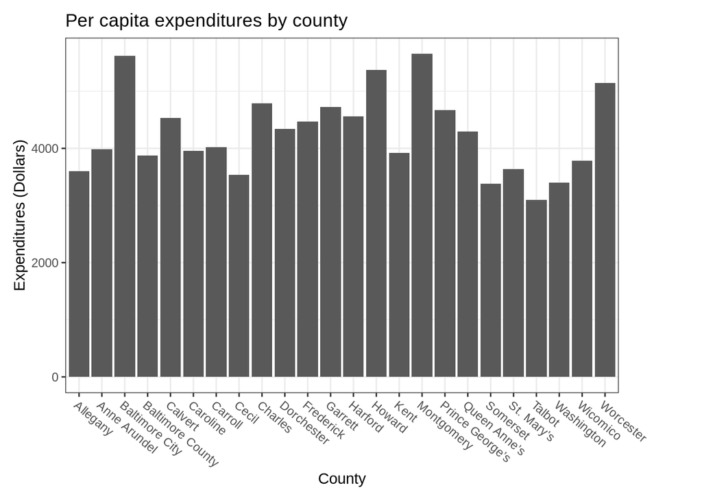

```r
ggplot(md_budget_clean) +
    geom_bar(aes(x = County, y = Expenditures), stat = "summary", fun.y = "sum") +
    labs(title = "Per capita expenditures by county",
         y = "Expenditures (Dollars)") +
    theme_bw() +
    theme(axis.text.x = element_text(angle = -40, hjust = 0), # Justification 0 = left, 1 = right
          plot.margin = margin(10, 60, 10, 10, "pt"))
```

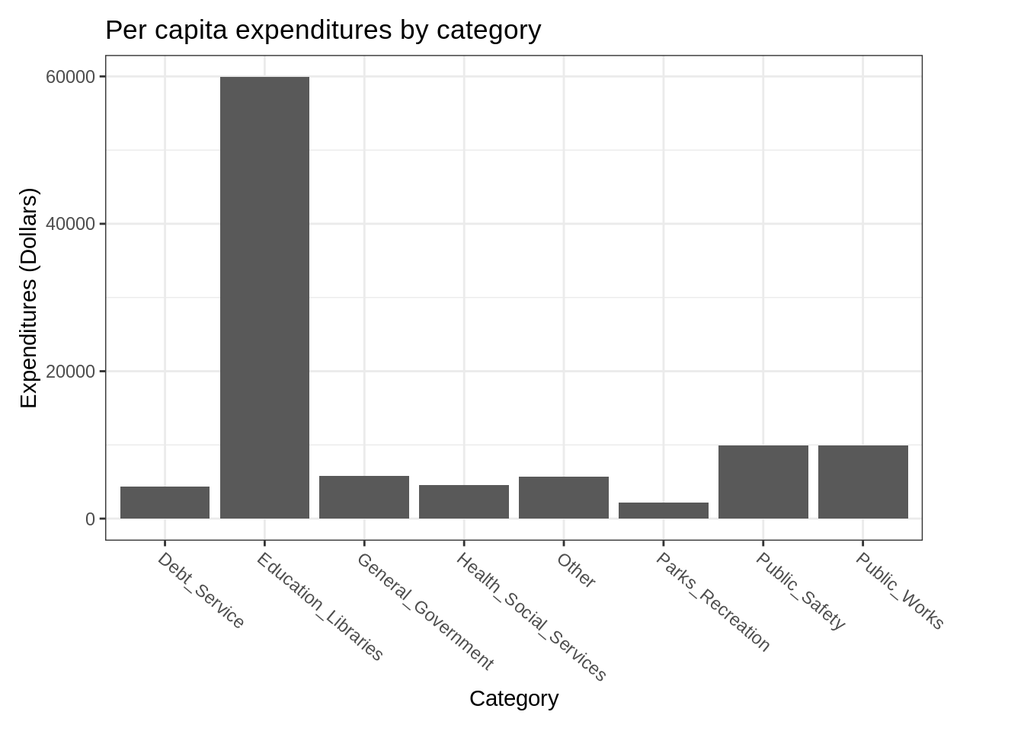

```r
ggplot(md_budget_clean) +
    geom_bar(aes(x = Category, y = Expenditures), stat = "summary", fun.y = "sum") +
    labs(title = "Per capita expenditures by category",
         y = "Expenditures (Dollars)") +
    theme_bw() +
    theme(axis.text.x = element_text(angle = -40, hjust = 0), # Justification 0 = left, 1 = right
          plot.margin = margin(10, 50, 10, 10, "pt"))
```

The highest spending per capita is in the category of Education and Libraries. Compare the spending in this category alone across all counties.

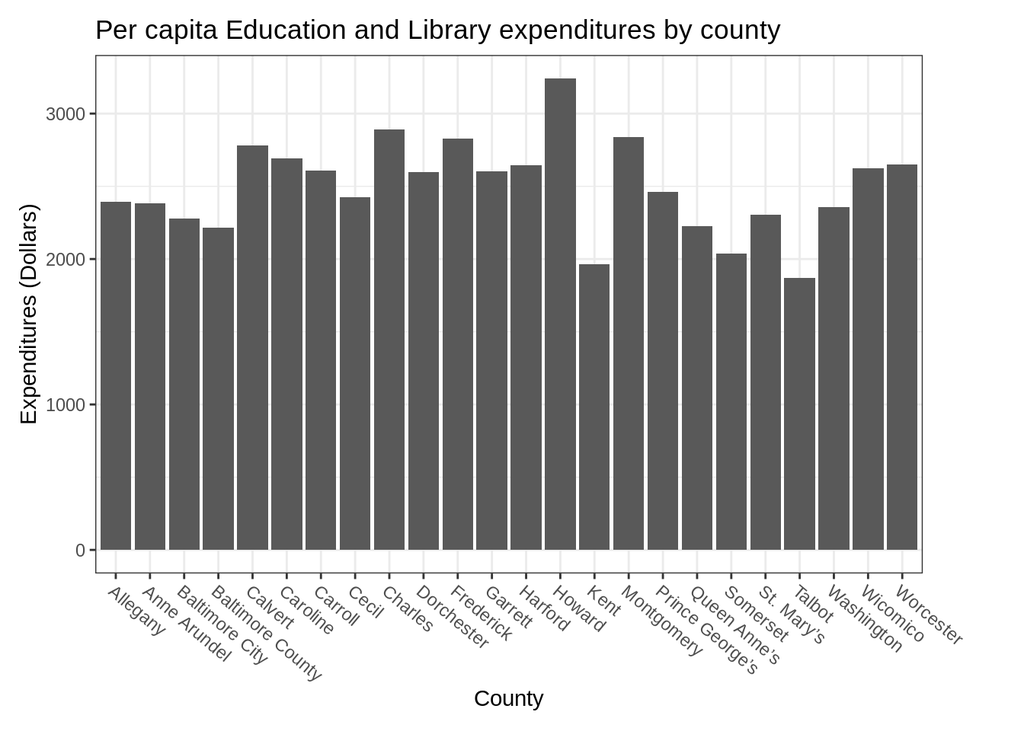

```r
ggplot(subset(md_budget_clean, Category == "Education_Libraries")) +
    geom_bar(aes(x = County, y = Expenditures), stat = "identity") +
    labs(title = "Per capita Education and Library expenditures by county",
         y = "Expenditures (Dollars)") +
    theme_bw() +
    theme(axis.text.x = element_text(angle = -40, hjust = 0), # Justification 0 = left, 1 = right
          plot.margin = margin(10, 50, 10, 10, "pt"))
```